# Eample saspy notebook showing the python interface to SAS

# Import HTML to use to display results from the LST

```python
from IPython.display import HTML
```

# Import the saspy module to get access to SAS

```python
import saspy
```

### Instantiate a SASsession object. This creates the SAS session that will be used for this notebook

```python
sas = saspy.SASsession()
```

```
Please enter the name of the SAS Config you wish to run. Available Configs are: ['default', 'http', 'httptest', 'ssh'] ssh
SAS Connection established. Subprocess id is 4556
```

### Delete the '#' sign bellow (comment), and put the cursor after the dot (.) and hit Tab. It will show you the methods available from the SASsession object

```python
#sas.
```

### Create a SASdata object to use to access the cars data set in the sashelp library.

```python
cars = sas.sasdata('cars', libref='sashelp')
```

### Again, remove the comment character, #, and after the dot, hit Tab to see the methods available on the SASdata object

```python
#cars.
```

```python
#cars.describe()
#cars.head()
cars.tail()
```

The SAS System

| Obs | Make | Model | Type | Origin | DriveTrain | MSRP | Invoice | EngineSize | Cylinders | Horsepower | MPG_City | MPG_Highway | Weight | Wheelbase | Length |
| --- | --- | --- | --- | --- | --- | --- | --- | --- | --- | --- | --- | --- | --- | --- | --- |
| 424 | Volvo | C70 LPT convertible 2dr | Sedan | Europe | Front | $40,565 | $38,203 | 2.4 | 5 | 197 | 21 | 28 | 3450 | 105 | 186 |
| 425 | Volvo | C70 HPT convertible 2dr | Sedan | Europe | Front | $42,565 | $40,083 | 2.3 | 5 | 242 | 20 | 26 | 3450 | 105 | 186 |
| 426 | Volvo | S80 T6 4dr | Sedan | Europe | Front | $45,210 | $42,573 | 2.9 | 6 | 268 | 19 | 26 | 3653 | 110 | 190 |
| 427 | Volvo | V40 | Wagon | Europe | Front | $26,135 | $24,641 | 1.9 | 4 | 170 | 22 | 29 | 2822 | 101 | 180 |
| 428 | Volvo | XC70 | Wagon | Europe | All | $35,145 | $33,112 | 2.5 | 5 | 208 | 20 | 27 | 3823 | 109 | 186 |

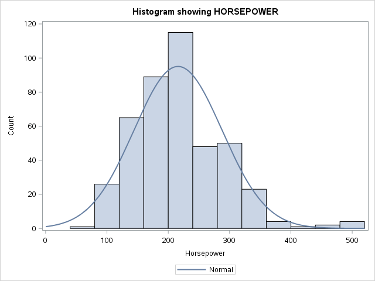

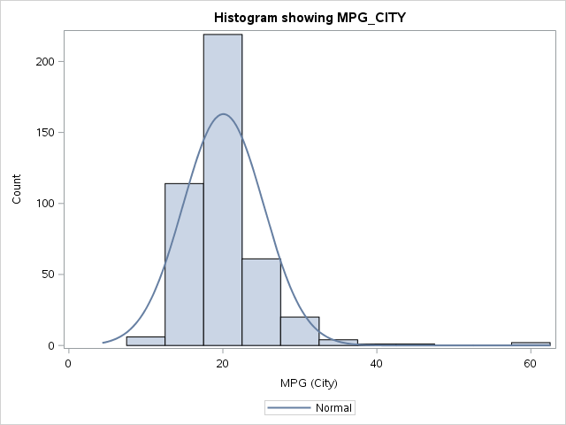

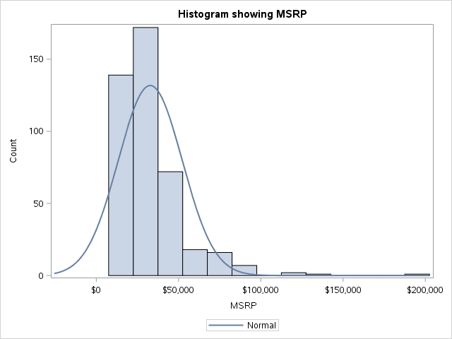

```python
for col in ['horsepower','MPG_City', 'MSRP']:
    cars.hist(col, title='Histogram showing '+col.upper())
```

#### Try out any other methods too. To see the method signature (parameters and return type) just type the method with a ? at the end and submit; **cars.hist?** This will pop up a window at the bottome and show information about the method.

```python
#cars.hist?
```

### The SASsession object has a **submit** method to submit any SAS code you want. It returns a dictionary with the LOG and the LST. You can print the log and HTML the results from the Listing. You can also prompt for macro variable substitution at runtime!

```python
 ll = sas.submit('data &dsname; user="&user"; hidden="&pw"; run; proc print data=&dsname;run;', prompt={'user': False, 'pw': True, 'dsname': False})
```

```
Please enter value for macro variable user sastpw
Please enter value for macro variable pw ········
Please enter value for macro variable dsname tom1
```

```python
HTML(ll['LST'])
```

'

| Obs | user | hidden |
| --- | --- | --- |
| 1 | sastpw | this is not my password |

```python
print(ll['LOG'])
```

```
60   ods listing close;ods html5 file=stdout options(bitmap_mode='inline') device=svg; ods graphics on / outputfmt=png;
NOTE: Writing HTML5 Body file: STDOUT
61
62   options nosource nonotes;
67   data &dsname; user="&user"; hidden="&pw"; run; proc print data=&dsname;run;
NOTE: The data set WORK.TOM1 has 1 observations and 2 variables.
NOTE: DATA statement used (Total process time):
      real time           0.00 seconds
      cpu time            0.00 seconds

NOTE: There were 1 observations read from the data set WORK.TOM1.
NOTE: PROCEDURE PRINT used (Total process time):
      real time           0.00 seconds
      cpu time            0.01 seconds

68   options nosource nonotes;
73
74   ods html5 close;ods listing;

75
```

```python
#cars.
```

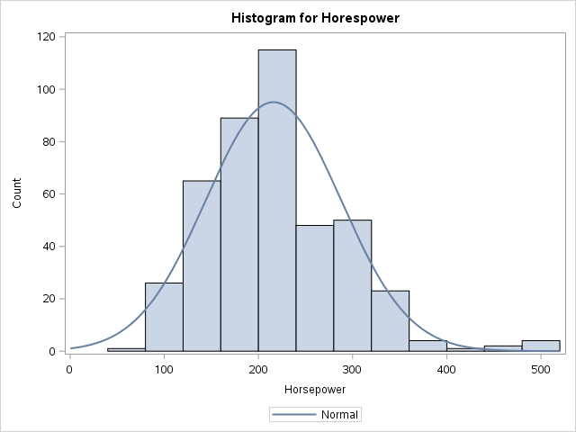

```python
cars.hist('horsepower', title='Histogram for Horespower')
```

#### You can always see the entire session log by using the saslog() method of the SASsession object.

```python
#print(sas.saslog())
```

```python
ll = sas.submit('libname work list;')
```

```python
print(ll['LOG'])
```

```
89   ods listing close;ods html5 file=stdout options(bitmap_mode='inline') device=svg; ods graphics on / outputfmt=png;
NOTE: Writing HTML5 Body file: STDOUT
90
91   libname work list;
NOTE: Libref=   WORK
      Scope=    Kernel
      Engine=   V9
      Access=   TEMP
      Physical Name= /tmp/SAS_work7F250000113D_tom64-2
      Filename= /tmp/SAS_work7F250000113D_tom64-2
      Inode Number= 262147
      Access Permission= rwx------
      Owner Name= sas
      File Size=              4KB
      File Size (bytes)= 4096
92
93   ods html5 close;ods listing;

94
```

## Want to read and write CSV files?

```python
cars.to_csv('/tmp/cars.csv')
```

```
96
97   options nosource;
NOTE: The file X is:
      Filename=/tmp/cars.csv,
      Owner Name=sas,Group Name=sas,
      Access Permission=-rw-rw-r--,
      Last Modified=15Jun2016:15:52:13

NOTE: 429 records were written to the file X.
      The minimum record length was 68.
      The maximum record length was 123.
NOTE: There were 428 observations read from the data set SASHELP.CARS.
NOTE: DATA statement used (Total process time):
      real time           0.00 seconds
      cpu time            0.00 seconds

428 records created in X from SASHELP.CARS.


NOTE: "X" file was successfully created.
NOTE: PROCEDURE EXPORT used (Total process time):
      real time           0.06 seconds
      cpu time            0.05 seconds

184
185
186
```

```python
carscsv = sas.read_csv('/tmp/cars.csv', 'cars_cvs')
```

```python
carscsv.tail(7)
```

'

| Obs | Make | Model | Type | Origin | DriveTrain | MSRP | Invoice | EngineSize | Cylinders | Horsepower | MPG_City | MPG_Highway | Weight | Wheelbase | Length |
| --- | --- | --- | --- | --- | --- | --- | --- | --- | --- | --- | --- | --- | --- | --- | --- |
| 422 | Volvo | S80 2.9 4dr | Sedan | Europe | Front | $37,730 | $35,542 | 2.9 | 6 | 208 | 20 | 28 | 3576 | 110 | 190 |
| 423 | Volvo | S80 2.5T 4dr | Sedan | Europe | All | $37,885 | $35,688 | 2.5 | 5 | 194 | 20 | 27 | 3691 | 110 | 190 |
| 424 | Volvo | C70 LPT convertible 2dr | Sedan | Europe | Front | $40,565 | $38,203 | 2.4 | 5 | 197 | 21 | 28 | 3450 | 105 | 186 |
| 425 | Volvo | C70 HPT convertible 2dr | Sedan | Europe | Front | $42,565 | $40,083 | 2.3 | 5 | 242 | 20 | 26 | 3450 | 105 | 186 |
| 426 | Volvo | S80 T6 4dr | Sedan | Europe | Front | $45,210 | $42,573 | 2.9 | 6 | 268 | 19 | 26 | 3653 | 110 | 190 |
| 427 | Volvo | V40 | Wagon | Europe | Front | $26,135 | $24,641 | 1.9 | 4 | 170 | 22 | 29 | 2822 | 101 | 180 |
| 428 | Volvo | XC70 | Wagon | Europe | All | $35,145 | $33,112 | 2.5 | 5 | 208 | 20 | 27 | 3823 | 109 | 186 |

```python
 carscsv.means()
```

'

The MEANS Procedure

| Variable | N | Mean | Std Dev | Minimum | 25th Pctl | 50th Pctl | 75th Pctl | Maximum |
| --- | --- | --- | --- | --- | --- | --- | --- | --- |
| EngineSize Cylinders Horsepower MPG_City MPG_Highway Weight Wheelbase Length | 428 426 428 428 428 428 428 428 | 3.1967290 5.8075117 215.8855140 20.0607477 26.8434579 3577.95 108.1542056 186.3621495 | 1.1085947 1.5584426 71.8360316 5.2382176 5.7412007 758.9832146 8.3118130 14.3579913 | 1.3000000 3.0000000 73.0000000 10.0000000 12.0000000 1850.00 89.0000000 143.0000000 | 2.3500000 4.0000000 165.0000000 17.0000000 24.0000000 3103.00 103.0000000 178.0000000 | 3.0000000 6.0000000 210.0000000 19.0000000 26.0000000 3474.50 107.0000000 187.0000000 | 3.9000000 6.0000000 255.0000000 21.5000000 29.0000000 3978.50 112.0000000 194.0000000 | 8.3000000 12.0000000 500.0000000 60.0000000 66.0000000 7190.00 144.0000000 238.0000000 |

## We can transfer data between SAS Data Sets and Pandas Data Frames

```python
import pandas
```

```python
car_df = cars.to_df()
```

```python
car_df.head()
```

|  | Make | Model | Type | Origin | DriveTrain | MSRP | Invoice | EngineSize | Cylinders | Horsepower | MPG_City | MPG_Highway | Weight | Wheelbase | Length |
| --- | --- | --- | --- | --- | --- | --- | --- | --- | --- | --- | --- | --- | --- | --- | --- |
| 0 | Acura | MDX | SUV | Asia | All | 36945 | 33337 | 3.5 | 6.0 | 265 | 17 | 23 | 4451 | 106 | 189 |
| 1 | Acura | RSX Type S 2dr | Sedan | Asia | Front | 23820 | 21761 | 2.0 | 4.0 | 200 | 24 | 31 | 2778 | 101 | 172 |
| 2 | Acura | TSX 4dr | Sedan | Asia | Front | 26990 | 24647 | 2.4 | 4.0 | 200 | 22 | 29 | 3230 | 105 | 183 |
| 3 | Acura | TL 4dr | Sedan | Asia | Front | 33195 | 30299 | 3.2 | 6.0 | 270 | 20 | 28 | 3575 | 108 | 186 |
| 4 | Acura | 3.5 RL 4dr | Sedan | Asia | Front | 43755 | 39014 | 3.5 | 6.0 | 225 | 18 | 24 | 3880 | 115 | 197 |

```python
cars.head()
```

'

| Obs | Make | Model | Type | Origin | DriveTrain | MSRP | Invoice | EngineSize | Cylinders | Horsepower | MPG_City | MPG_Highway | Weight | Wheelbase | Length |
| --- | --- | --- | --- | --- | --- | --- | --- | --- | --- | --- | --- | --- | --- | --- | --- |
| 1 | Acura | MDX | SUV | Asia | All | $36,945 | $33,337 | 3.5 | 6 | 265 | 17 | 23 | 4451 | 106 | 189 |
| 2 | Acura | RSX Type S 2dr | Sedan | Asia | Front | $23,820 | $21,761 | 2.0 | 4 | 200 | 24 | 31 | 2778 | 101 | 172 |
| 3 | Acura | TSX 4dr | Sedan | Asia | Front | $26,990 | $24,647 | 2.4 | 4 | 200 | 22 | 29 | 3230 | 105 | 183 |
| 4 | Acura | TL 4dr | Sedan | Asia | Front | $33,195 | $30,299 | 3.2 | 6 | 270 | 20 | 28 | 3575 | 108 | 186 |
| 5 | Acura | 3.5 RL 4dr | Sedan | Asia | Front | $43,755 | $39,014 | 3.5 | 6 | 225 | 18 | 24 | 3880 | 115 | 197 |

```python
car_df.dtypes
```

```
Make            object
Model           object
Type            object
Origin          object
DriveTrain      object
MSRP             int64
Invoice          int64
EngineSize     float64
Cylinders      float64
Horsepower       int64
MPG_City         int64
MPG_Highway      int64
Weight           int64
Wheelbase        int64
Length           int64
dtype: object
```

```python
cars.contents()
```

'

The CONTENTS Procedure

| Data Set Name | SASHELP.CARS | Observations | 428 |
| --- | --- | --- | --- |
| Member Type | DATA | Variables | 15 |
| Engine | V9 | Indexes | 0 |
| Created | 05/27/2015 21:17:15 | Observation Length | 152 |
| Last Modified | 05/27/2015 21:17:15 | Deleted Observations | 0 |
| Protection |  | Compressed | NO |
| Data Set Type |  | Sorted | YES |
| Label | 2004 Car Data |  |  |
| Data Representation | SOLARIS_X86_64, LINUX_X86_64, ALPHA_TRU64, LINUX_IA64 |  |  |
| Encoding | us-ascii ASCII (ANSI) |  |  |

| Engine/Host Dependent Information |  |
| --- | --- |
| Data Set Page Size | 65536 |
| Number of Data Set Pages | 2 |
| First Data Page | 1 |
| Max Obs per Page | 430 |
| Obs in First Data Page | 405 |
| Number of Data Set Repairs | 0 |
| Filename | /opt/tom/sasutf8/SASFoundation/9.4/sashelp/cars.sas7bdat |
| Release Created | 9.0401M3 |
| Host Created | Linux |
| Inode Number | 7209257 |
| Access Permission | rw-r--r-- |
| Owner Name | sastpw |
| File Size | 192KB |
| File Size (bytes) | 196608 |

| Alphabetic List of Variables and Attributes # | Alphabetic List of Variables and Attributes Variable | Alphabetic List of Variables and Attributes Type | Alphabetic List of Variables and Attributes Len | Alphabetic List of Variables and Attributes Format | Alphabetic List of Variables and Attributes Label |
| --- | --- | --- | --- | --- | --- |
| 9 | Cylinders | Num | 8 |  |  |
| 5 | DriveTrain | Char | 5 |  |  |
| 8 | EngineSize | Num | 8 |  | Engine Size (L) |
| 10 | Horsepower | Num | 8 |  |  |
| 7 | Invoice | Num | 8 | DOLLAR8. |  |
| 15 | Length | Num | 8 |  | Length (IN) |
| 11 | MPG_City | Num | 8 |  | MPG (City) |
| 12 | MPG_Highway | Num | 8 |  | MPG (Highway) |
| 6 | MSRP | Num | 8 | DOLLAR8. |  |
| 1 | Make | Char | 13 |  |  |
| 2 | Model | Char | 40 |  |  |
| 4 | Origin | Char | 6 |  |  |
| 3 | Type | Char | 8 |  |  |
| 13 | Weight | Num | 8 |  | Weight (LBS) |
| 14 | Wheelbase | Num | 8 |  | Wheelbase (IN) |

| Sort Information |  |
| --- | --- |
| Sortedby | Make Type |
| Validated | YES |
| Character Set | ANSI |

Data Frames **describe** method matches up with our Proc Means. SASdata object has the **describe** method (and **means** as an alias method)

```python
car_df.describe()
```

|  | MSRP | Invoice | EngineSize | Cylinders | Horsepower | MPG_City | MPG_Highway | Weight | Wheelbase | Length |
| --- | --- | --- | --- | --- | --- | --- | --- | --- | --- | --- |
| count | 428.000000 | 428.000000 | 428.000000 | 426.000000 | 428.000000 | 428.000000 | 428.000000 | 428.000000 | 428.000000 | 428.000000 |
| mean | 32774.855140 | 30014.700935 | 3.196729 | 5.807512 | 215.885514 | 20.060748 | 26.843458 | 3577.953271 | 108.154206 | 186.362150 |
| std | 19431.716674 | 17642.117750 | 1.108595 | 1.558443 | 71.836032 | 5.238218 | 5.741201 | 758.983215 | 8.311813 | 14.357991 |
| min | 10280.000000 | 9875.000000 | 1.300000 | 3.000000 | 73.000000 | 10.000000 | 12.000000 | 1850.000000 | 89.000000 | 143.000000 |
| 25% | 20334.250000 | 18866.000000 | 2.375000 | NaN | 165.000000 | 17.000000 | 24.000000 | 3104.000000 | 103.000000 | 178.000000 |
| 50% | 27635.000000 | 25294.500000 | 3.000000 | NaN | 210.000000 | 19.000000 | 26.000000 | 3474.500000 | 107.000000 | 187.000000 |
| 75% | 39205.000000 | 35710.250000 | 3.900000 | NaN | 255.000000 | 21.250000 | 29.000000 | 3977.750000 | 112.000000 | 194.000000 |
| max | 192465.000000 | 173560.000000 | 8.300000 | 12.000000 | 500.000000 | 60.000000 | 66.000000 | 7190.000000 | 144.000000 | 238.000000 |

```python
cars.describe()
```

'

The MEANS Procedure

| Variable | Label | N | Mean | Std Dev | Minimum | 25th Pctl | 50th Pctl | 75th Pctl | Maximum |
| --- | --- | --- | --- | --- | --- | --- | --- | --- | --- |
| MSRP Invoice EngineSize Cylinders Horsepower MPG_City MPG_Highway Weight Wheelbase Length | Engine Size (L) MPG (City) MPG (Highway) Weight (LBS) Wheelbase (IN) Length (IN) | 428 428 428 426 428 428 428 428 428 428 | 32774.86 30014.70 3.1967290 5.8075117 215.8855140 20.0607477 26.8434579 3577.95 108.1542056 186.3621495 | 19431.72 17642.12 1.1085947 1.5584426 71.8360316 5.2382176 5.7412007 758.9832146 8.3118130 14.3579913 | 10280.00 9875.00 1.3000000 3.0000000 73.0000000 10.0000000 12.0000000 1850.00 89.0000000 143.0000000 | 20329.50 18851.00 2.3500000 4.0000000 165.0000000 17.0000000 24.0000000 3103.00 103.0000000 178.0000000 | 27635.00 25294.50 3.0000000 6.0000000 210.0000000 19.0000000 26.0000000 3474.50 107.0000000 187.0000000 | 39215.00 35732.50 3.9000000 6.0000000 255.0000000 21.5000000 29.0000000 3978.50 112.0000000 194.0000000 | 192465.00 173560.00 8.3000000 12.0000000 500.0000000 60.0000000 66.0000000 7190.00 144.0000000 238.0000000 |

## Now round trip the Data Frame back to a SAS Data Set

```python
cars_full_circle = sas.df2sd(car_df, 'cfc')
```

```python
cars_full_circle.describe()
```

'

The MEANS Procedure

| Variable | N | Mean | Std Dev | Minimum | 25th Pctl | 50th Pctl | 75th Pctl | Maximum |
| --- | --- | --- | --- | --- | --- | --- | --- | --- |
| MSRP Invoice EngineSize Cylinders Horsepower MPG_City MPG_Highway Weight Wheelbase Length | 428 428 428 426 428 428 428 428 428 428 | 32774.86 30014.70 3.1967290 5.8075117 215.8855140 20.0607477 26.8434579 3577.95 108.1542056 186.3621495 | 19431.72 17642.12 1.1085947 1.5584426 71.8360316 5.2382176 5.7412007 758.9832146 8.3118130 14.3579913 | 10280.00 9875.00 1.3000000 3.0000000 73.0000000 10.0000000 12.0000000 1850.00 89.0000000 143.0000000 | 20329.50 18851.00 2.3500000 4.0000000 165.0000000 17.0000000 24.0000000 3103.00 103.0000000 178.0000000 | 27635.00 25294.50 3.0000000 6.0000000 210.0000000 19.0000000 26.0000000 3474.50 107.0000000 187.0000000 | 39215.00 35732.50 3.9000000 6.0000000 255.0000000 21.5000000 29.0000000 3978.50 112.0000000 194.0000000 | 192465.00 173560.00 8.3000000 12.0000000 500.0000000 60.0000000 66.0000000 7190.00 144.0000000 238.0000000 |

# Now let's look at the SASstat object!

```python
stat = sas.sasstat()
```

```python
#stat.                 # use the 'dot Tab ' to see the methods available
```

### Let's run a regression which will return us a SASresults object that we can use to see any/all of the results

```python
stat_results = stat.reg(model='horsepower = Cylinders EngineSize', data=cars)
```

### What results are available?

```python
dir(stat_results)
```

```
['ANOVA',
 'COOKSDPLOT',
 'DFBETASPANEL',
 'DFFITSPLOT',
 'DIAGNOSTICSPANEL',
 'FITSTATISTICS',
 'NOBS',
 'OBSERVEDBYPREDICTED',
 'PARAMETERESTIMATES',
 'QQPLOT',
 'RESIDUALBOXPLOT',
 'RESIDUALBYPREDICTED',
 'RESIDUALHISTOGRAM',
 'RESIDUALPLOT',
 'RFPLOT',
 'RSTUDENTBYLEVERAGE',
 'RSTUDENTBYPREDICTED']
```

### Pick any one you want ...

DIAGNOSTICSPANEL

'

The REG Procedure

Model: MODEL1

Dependent Variable: Horsepower

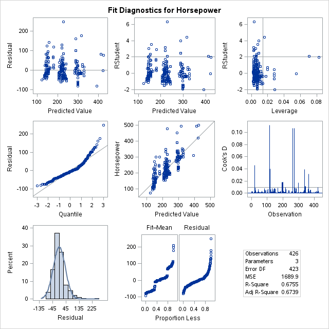

```python
stat_results.DIAGNOSTICSPANEL
```

### Or display them ALL (Click in the pannel to the Left of the results below to expand/shrink the result pane)

```python
#stat_results.ALL()
```

### Proc SQL anyone???

#### And you can use the SASLIB method of the SASsession to assign any data you like (Teradata, Hadoop, ...)

```python
#sas.saslib('Tera', engine='Teradata', options='user=me pw=mypw server=teracop1')
ll = sas.submit('proc sql; create table sales as select month, sum(actual) as tot_sales, sum(predict) as predicted_sales from sashelp.prdsale group by 1 order by month ;quit;')
sales = sas.sasdata('sales')
```

```python
print(ll['LOG']);HTML(ll['LST'])
```

```
1078  ods listing close;ods html5 file=stdout options(bitmap_mode='inline') device=svg; ods graphics on / outputfmt=png;
NOTE: Writing HTML5 Body file: STDOUT
1079
1080  proc sql;
1080!           create table sales as select month, sum(actual) as tot_sales, sum(predict) as predicted_sales from sashelp.prdsale
1080! group by 1 order by month ;quit;
NOTE: Table WORK.SALES created, with 24 rows and 3 columns.

NOTE: PROCEDURE SQL used (Total process time):
      real time           0.00 seconds
      cpu time            0.02 seconds

1081
1082  ods html5 close;ods listing;

1083
```

### Let's chart our sales for the aggregate table we created with the Proc SQL

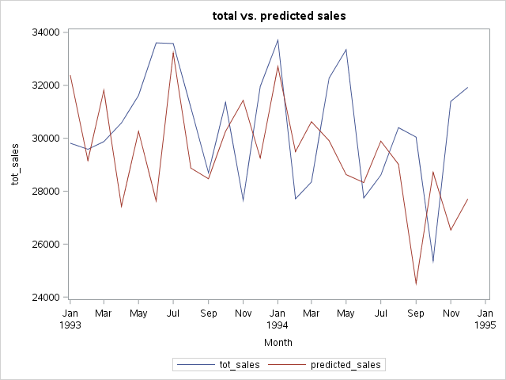

```python
sales.series(y=['tot_sales','predicted_sales'], x='month', title='total vs. predicted sales')
```

## Try the ETS object; including cheking an error case first

```python
ets = sas.sasets()
```

```python
ets_results = ets.arima(model='horsepower = Cylinders EngineSize', data=cars)
```

```
You are missing 1 required statements:
{'identify'}
Error in code submission
```

```python
dir(ets_results)
```

```
[]
```

```python
ets_results.PLOT
```

```
Result named PLOT not found. Valid results are:[]
```

```python
ets_results = ets.timeid(id='horsepower', data=cars)
```

```python
dir(ets_results)
```

```
['DECOMPOSITIONPLOT',
 'INTERVALCOUNTSCOMPONENTPLOT',
 'OFFSETCOMPONENTPLOT',
 'SPANCOMPONENTPLOT',
 'VALUESPLOT']
```

DECOMPOSITIONPLOT

'

The TIMEID Procedure

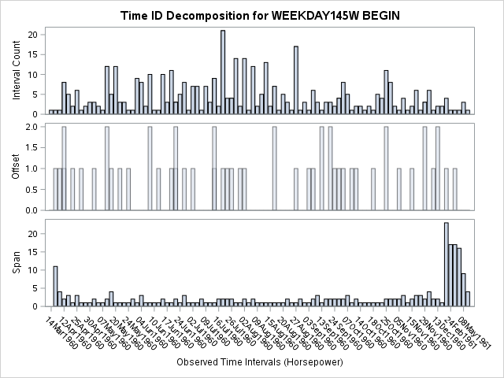

```python
ets_results.DECOMPOSITIONPLOT
```

```python
#ets_results.ALL()
```

## How would we get these results in a batch python script? Set batch to True and get the HTML returned to you to write out to a file and view later

```python
sas.set_batch (True)
```

```python
q = ets_results.DECOMPOSITIONPLOT
```

### q is the Dict with the LOG and LST. The LST is the HTML of the result. We'll display it here, but if you write it to a file it will render when you open it in a web browser too.

'

The TIMEID Procedure

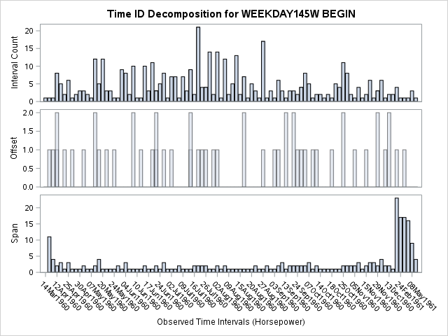

```python
HTML(q['LST'])
```

### the ALL() method returns a List of Dict's which is easy to traverse. Can write them out to their own files to view later. Just display them here for now.

```python
from IPython.display import display as DIS
x = ets_results.ALL()
for i in range(len(x)):
    DIS(HTML(x[i]['LST']))
```

[output not shown]

```python
sas.set_batch (False)
```

## The following isn't needed, SAS will shutdown when you stop the notebook. But you can shut it down manually if you want

```python
sas._endsas()
```

```
SAS Connection terminated. Subprocess id was 4556
```